# Définition

```python
%matplotlib inline

import numpy as np
import matplotlib.pyplot as plt
from math import *
```

### Parameters

```python
a = -10.0
b = 10.0

x_range = range(1, 21)
degree = 5
```

### Function to be integrated

```python
def f(x, n = degree):
    if n == 0:
        return 1
    return x ** n + f(x, n - 1)
```

### Analytic Primitive

```python
def F(x, n = degree):
    if n + 1 == 0:
        return 0
    return x ** (n + 1) / (n + 1) + F(x, n - 1)
```

## Graph

```
Integral : 40686.6666667
```

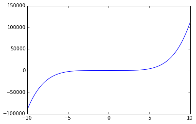

```python
rng = 200
step = (b - a)/(rng - 1)
x = [ a + i * step for i in range(0, rng)]
fx = [ f(i) for i in x]

#
figure_function = plt.figure()
ax = figure_function.add_subplot(111)
ax.plot(x, fx)

inte_analytic = F(b) - F(a)
print 'Integral : ' + str(inte_analytic)
```

# Formules de quadrature

## Newton-Cotes

Forme générale: $\int_a^b f(x)dx \approx \sum_{j = 0}^n w_j f(x_j)$

### Riemann integral

call : $1 \times n \times f$ $\int_a^b f(x)dx \approx (b - a) f\bigg(\frac{b + a}{2}\bigg)$

```
Simple Rectangle   : 20.0
Composed Rectangle : 40673.2676
```

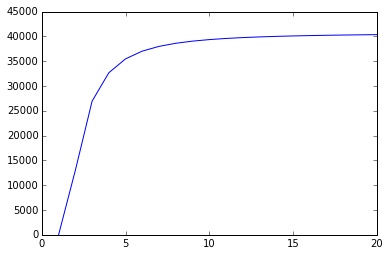

```python
def int_rectangle(f, a, b):
    return (b - a) * f((a + b)/2)

def composed_rectangle(f, a, b, n):
    step = (b - a)/n
    inte = 0.0

    for i in range(0, n):
        inte = inte + int_rectangle(f, a + i * step, a + (i + 1.0) * step)

    return inte

print 'Simple Rectangle   : ' + str(int_rectangle(f, a, b))
print 'Composed Rectangle : ' + str(composed_rectangle(f, a, b, 100))

evol_rect = [composed_rectangle(f, a, b, i) for i in x_range]

figure_rect = plt.figure()
ax = figure_rect.add_subplot(111)
ax.plot(x_range, evol_rect)
```

### Trapèze

call : $2 \times n \times f$ $\int_a^b f(x)dx \approx (b - a) \frac{f(a) + f(b)}{2}$

```
Simple Trapeze   : 202020.0
Composed Trapeze : 40713.4656
```

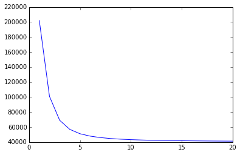

```python
def int_trapeze(f, a, b):
    return (b - a) * (f(a) + f(b))/2.0

def composed_trapeze(f, a, b, n):
    """ we can save ~~ n f() call if we implement the right composed rule """
    step = (b - a)/n
    inte = 0.0

    for i in range(0, n):
        inte = inte + int_trapeze(f, a + i * step, a + (i + 1.0) * step)

    return inte

print 'Simple Trapeze   : ' + str(int_trapeze(f, a, b))
print 'Composed Trapeze : ' + str(composed_trapeze(f, a, b, 100))

evol_trapeze = [composed_trapeze(f, a, b, i) for i in x_range]

figure_trapeze = plt.figure()
ax = figure_trapeze.add_subplot(111)
ax.plot(x_range, evol_trapeze)
```

### Simpson

Approximation quadratique (d=2)

call : $3 \times n \times f$ $\int_a^b f(x)dx \approx \frac{(b - a)}{6} \bigg[f(a) + 4 f\bigg(\frac{a + b}{2}\bigg) + f(b)\bigg]$

```
Simple simpson   : 67353.3333333
Composed simpson : 40686.8333333
```

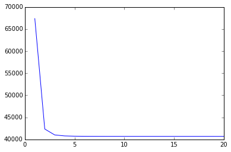

```python
def int_simpson(f, a, b):
    return (b - a) * (f(a) + 4.0 * f((a + b)/2.0)+ f(b))/6.0

def composed_simpson(f, a, b, n):
    step = (b - a)/n
    inte = 0.0

    for i in range(0, n):
        inte = inte + int_simpson(f, a + i * step, a + (i + 1.0) * step)

    return inte

print 'Simple simpson   : ' + str(int_simpson(f, a, b))
print 'Composed simpson : ' + str(composed_simpson(f, a, b, 20))

evol_simpson = [composed_simpson(f, a, b, i) for i in x_range]

figure_simpson = plt.figure()
ax = figure_simpson.add_subplot(111)
ax.plot(x_range, evol_simpson)
```

## Quadrature Gaussienne

on va choisir les poids et les noeuds en même temps

$\int_a^b f(x)dx \approx \sum_{j = 1}^n w_j f(x_j)$ call : $1 \times n \times f$

forme générale:

Orthogonaux $\int_a^b \varphi_k (x) \varphi_l(x) w(x) dx = 0 \ si\ k \not= l$

Orthonormaux $\int_a^b \varphi_k (x) \varphi_l(x) w(x) dx =\begin{align*} 0 \ si\ k \not= l \\ 1 \ si\ k = l \end{align*}$

Weights are given by $w_i = - \frac{q_{n + 1} / q_n}{\varphi_n' \varphi_{n + 1}(x_i)}$

### Gauss-Legendre

really good for polynomials. The approximation can be perfect after only 3 nodes !!

$w(x) = 1 \ \ x \in [-1, 1]$

```python
def gauss_legendre(f, a, b, n):
    if n == 1:
        t = [0.0]
        w = [2.0]
    elif n == 2:
        t = [-1.0/sqrt(3.0), +1.0/sqrt(3.0)]
        w = [1.0, 1.0]
    else:
        t = [-sqrt(3.0/5.0), 0.0, +sqrt(3.0/5.0)]
        w = [5.0/9.0, 8.0/9.0, 5.0/9.0]

    ret = 0
    for i in range(0, min(n, 3)):
        ret = ret + f((b - a) * t[i]/2.0 + (b + a)/2.0) * w[i]

    return  ret * (b - a) / 2.0

print 'Gauss-Legendre 1: ' + str(gauss_legendre(f, a, b, 1))
print 'Gauss-Legendre 2: ' + str(gauss_legendre(f, a, b, 2))
print 'Gauss-Legendre 3: ' + str(gauss_legendre(f, a, b, 3))
```

```
Gauss-Legendre 1: 20.0
Gauss-Legendre 2: 22908.8888889
Gauss-Legendre 3: 40686.6666667
```

### Gauss-Chebyshev

$w(x) = (1-x^2)^{-1/2} \ \ x \in [-1, 1]$

##### First Type

$\begin{eqnarray} t_i & = & cos\bigg( \frac{(2i - 1) \pi}{2n}\bigg) \\ w_i & = & \frac{\pi}{n} \end{eqnarray}$

```
Gauss-Chebyshev first: 40694.9775021
```

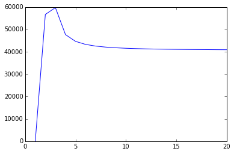

```python
def gauss_chebyshev_first(f, a, b, n):
    t = lambda x: cos((2.0 * x - 1.0) * pi / (2.0 * n))
    w = lambda x: pi / n
    ret = 0

    for i in range(1, n + 1):
        y = (b - a) * t(i)/2.0 + (b + a)/2.0

        ret = ret + f(y) * sqrt(1.0 - t(i) ** 2.0)

    return ret * (b - a) * pi / (2.0 * n)

print 'Gauss-Chebyshev first: ' + str(gauss_chebyshev_first(f, a, b, 100))

evol_chebyshev = [gauss_chebyshev_first(f, a, b, i) for i in x_range]

figure_chebyshev= plt.figure()
ax = figure_chebyshev.add_subplot(111)
ax.plot(x_range, evol_chebyshev)
```

##### Second Type

$\begin{eqnarray} t_i & = & cos\bigg( \frac{ i\pi}{n + 1}\bigg) \\ w_i & = & \frac{\pi}{n + 1} sin^2 \bigg( \frac{i}{n + 1} \pi\bigg) \end{eqnarray}$

```
Gauss-Chebyshev second: 40670.3751783
```

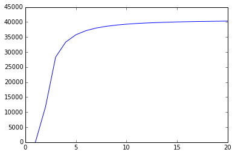

```python
def gauss_chebyshev_second(f, a, b, n):
    t = lambda x: cos(x * pi / (n + 1.0))
    w = lambda x:(sin(x * pi / (n + 1.0)) ** 2) * pi / (n + 1)
    ret = 0

    for i in range(1, n + 1):

        ret = ret + f((b - a) * t(i)/2.0 + (b + a)/2.0) * w(i) / sqrt(1.0 - t(i) ** 2.0)

    return (b - a) * ret / 2.0

print 'Gauss-Chebyshev second: ' + str(gauss_chebyshev_second(f, a, b, 100))

evol_chebyshev2 = [gauss_chebyshev_second(f, a, b, i) for i in x_range]

figure_chebyshev2 = plt.figure()
ax = figure_chebyshev2.add_subplot(111)
ax.plot(x_range, evol_chebyshev2)
```

### Gauss-Laguerre

```python
# poids Gauss-Hermite
x = [
    5.387480890011232862017,
    4.603682449550744273078,
    3.944764040115625210376,
    3.347854567383216326915,
    2.788806058428130480525,
    2.254974002089275523082,
    1.738537712116586206781,
    1.234076215395323007886,
    0.7374737285453943587056,
    0.2453407083009012499038,]

w = [
    2.22939364553415129252E-13,
    4.3993409922731805536E-10,
    1.086069370769281694E-7,
    7.8025564785320636941E-6,
    2.28338636016353967257E-4,
    0.00324377334223786183218,
    0.02481052088746361088216,
    0.1090172060200233200138,
    0.2866755053628341297197,
    0.4622436696006100896503]

mu = 0
sig = 1

a2 = - 10.0
b2 = 10.0

def norm(x):
    return exp(- (x ** 2.0) / 2.0) / sqrt(2.0 * pi)

def gauss_hermite(f, n = 20):
    inte = 0

    chg_var = lambda x: mu + sqrt(2) * x

    for i in range(0, 10):
        inte = inte + f(chg_var(x[i])) * w[i] + f(chg_var(-x[i])) * w[i]

    return inte /  sqrt(pi)

print 'Should be     : ' + str(exp(mu + sig ** 2.0 /2.0))
print 'Gauss Hermite : ' + str(gauss_hermite(exp))
print 'Simpsons      : ' + str(composed_simpson(lambda x: norm(x) * exp(x), a2, b2, 30))
```

```
Should be     : 1.6487212707
Gauss Hermite : 1.6487212707
Simpsons      : 1.6487212707
```

## Intégration à la Monte Carlo

```
Monte Carlo : 42903.8414563
```

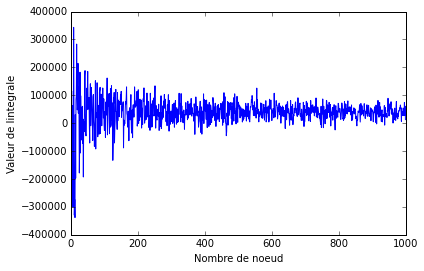

```python
def monte_carlo_inte(f, a, b, n):
    ret = 0
    for i in range(0, n):
        r = np.random.uniform(a, b)
        ret = ret + f(r)

    return (b - a) * ret/n

print 'Monte Carlo : ' + str(monte_carlo_inte(f, a, b, 10000))

evol_mc = [monte_carlo_inte(f, a, b, i) for i in range(1, 1000)]

figure_mc = plt.figure()
ax = figure_mc.add_subplot(111)
ax.plot(range(1, 1000), evol_mc)
ax.axes.xaxis.set_label_text('Nombre de noeud')
ax.axes.yaxis.set_label_text('Valeur de l''integrale')
```

[output not shown]

[figure not shown]

```python
import matplotlib.gridspec as gridspec
gs = gridspec.GridSpec(5, 5)

figure_sum = plt.figure()

ax = figure_sum.add_subplot(gs[0:5, 0:4])

# ax.plot(x_range[1:10], evol_mc[101:110], label='Monte Carlo 100-110')
# ax.plot(x_range[1:10], evol_mc[1:10], label='Monte Carlo 1-10')
ax.plot(x_range[1:10], evol_chebyshev[1:10], label='Chebyshev 1')
ax.plot(x_range[1:10], evol_chebyshev2[1:10], label='Chebyshev 2')
ax.plot(x_range[1:10], evol_simpson[1:10], label='Simpson')
ax.plot(x_range[1:10], evol_trapeze[1:10], label='Trapeze')
ax.plot(x_range[1:10], evol_rect[1:10], label='Rectangle')
ax.axes.xaxis.set_label_text('Nombre de noeud')
ax.axes.yaxis.set_label_text('Valeur de l''integrale')

#bbox_to_anchor=(0., 1.02, 1., .102), loc=3,           mode="expand", borderaxespad=0.

ax.legend(bbox_to_anchor=(1, 0., 0.0, 0.), loc=3, borderaxespad=0.6)

print '              ' + str('     std     ') + '  ' + str('     Int     ')
print 'Chebyshev 1 : ' + str(np.array(evol_chebyshev[1:10]).std()) + '  ' + str(gauss_chebyshev_first(f, a, b, 100))
print 'Chebyshev 2 : ' + str(np.array(evol_chebyshev2[1:10]).std()) + '  ' + str(gauss_chebyshev_second(f, a, b, 100))
print 'Trapeze     : ' + str(np.array(evol_trapeze[1:10]).std()) + '  ' + str(composed_trapeze(f, a, b, 100))
print 'Rectangle   : ' + str(np.array(evol_rect[1:10]).std()) + '  ' + str(composed_rectangle(f, a, b, 100))
print 'Monte Carlo : ' + str(np.array(evol_mc[1:10]).std()) + '  ' + str(monte_carlo_inte(f, a, b, 10000))
print '------------------------------------------'
print 'Simpson     : ' + str(np.array(evol_simpson[1:10]).std()) + '  ' + str(composed_simpson(f, a, b, 100))
print 'Legendre    : ' + str('             ') + '  ' + str(gauss_legendre(f, a, b, 3))
print 'Analytic    : ' + str('             ') + '  ' + str(F(b) - F(a))
```

## Performance

[figure not shown]

[output not shown]

[figure not shown]

```python
def int_rectangle_right(f, a, b):
    return (b - a) * f(b)

def int_rectangle_left(f, a, b):
    return (b - a) * f(a)

def composed_rectangle_right(f, a, b, n):
    step = (b - a)/n
    inte = 0.0

    for i in range(0, n):
        inte = inte + int_rectangle_right(f, a + i * step, a + (i + 1.0) * step)

    return inte

def composed_rectangle_left(f, a, b, n):
    step = (b - a)/n
    inte = 0.0

    for i in range(0, n):
        inte = inte + int_rectangle_left(f, a + i * step, a + (i + 1.0) * step)

    return inte

print 'Composed Rectangle Right  : ' + str(composed_rectangle_right(f, a, b, 100))
print 'Composed Rectangle Central: ' + str(composed_rectangle(f, a, b, 100))
print 'Composed Rectangle Left   : ' + str(composed_rectangle_left(f, a, b, 100))

evol_rect_c = [composed_rectangle(f, a, b, i) for i in x_range]
evol_rect_r = [composed_rectangle_right(f, a, b, i) for i in x_range]
evol_rect_l = [composed_rectangle_left(f, a, b, i) for i in x_range]

figure_rect = plt.figure()
ax = figure_rect.add_subplot(111)

v = 1
ax.plot(x_range[v:], evol_rect_c[v:], label='Central')
ax.plot(x_range[v:], evol_rect_r[v:], label='Right')
ax.plot(x_range[v:], evol_rect_l[v:], label='Left')
# ax.plot(x_range[v:], (np.array(evol_rect_l[v:]) + np.array(evol_rect_c[v:]))/2, label='Mean')
ax.legend()
```